# Hinge Data Analysis: Impact of comments on Matches

Hinge is uniquely different from other dating platforms because it allows users to add a comment on the like they send. This extra feature considerably increases the degree of freedom a user can exert to increase the chances of a match. In this report I will be analyzing my past year Hinge data to find out if comments influence my matches and find out optimal comment strategy for future likes.

## Overall data summary

We start by looking at the total volume of interactions to understand the scale of data. We distinguish between matches resulting from a sent like and "free matches" (received directly). In this report I will only be focussing on matches I receive for the likes I send out and not free matches because I am mostly concerned with finding ideal comment choice.

```
Likes Sent: 1129 | Matches from Likes: 127 | Free Matches: 23
```

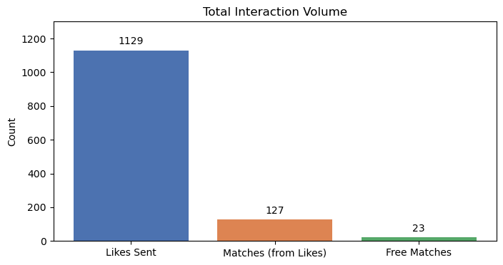

## 2. Match Success Rate: Comments vs No Comments

Next, we do the first simple analysis: check whether sending a comment with a like improves the probability of matching vs a like without any comment. Error bars represent the 95% Wilson confidence interval.

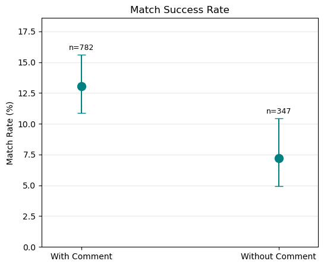

## 5. K-means clustering to identify different comment types

Not all comments I give out are the same. I use many canned comments and some variations of them. SOmetimes I also give more spontaneous comments. Instead of manually sorting through several hundered comments, I use K-means clustering along with Natural Language Processing to identify different comment types. I also further used my domain knowledge to further classify certain comments. Below is the visualization of how all the comments are clustered next to each other. As you can see certain clusters are very apparent while other clusters are much more spread and not easily grouped together.

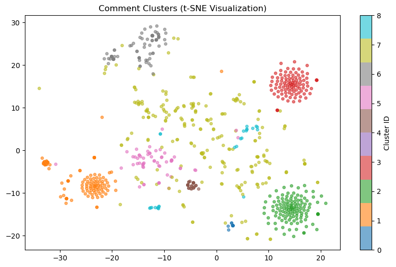

## 6. Cluster Success Rates

Match rates per cluster, named by the comment closest to the centroid.

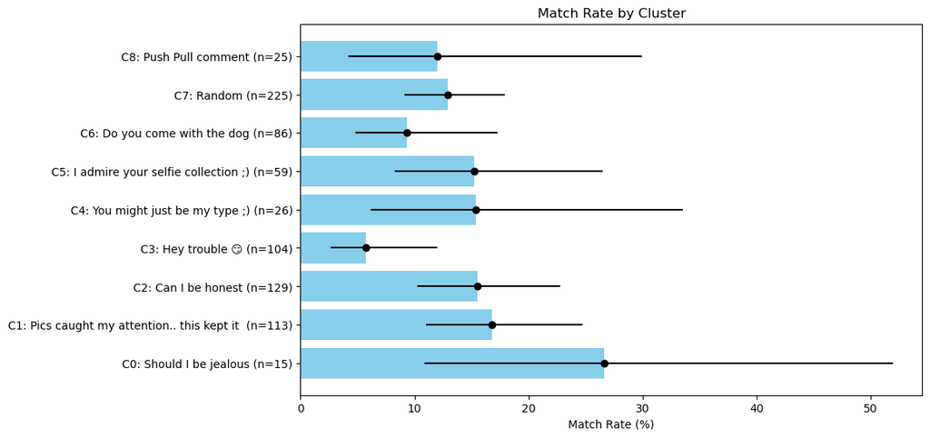

It seems that canned comments like C1 and C2 are quite good while one in C3 performs subpar. Random/spontaneous comments also are equivalent to the canned comments C1 and C2. So the extra effort spent on coming up with tailored/spontaneous comments may not be worth it. Finally, the high success rate of C0 is interesting and I should try testing it out more to get better statistics on it.

## 3. Confounding variable in time

The above analysis assumes all likes in a particular category are equivalent. However, there might be additional confounding variables. One likely confoundding variable can be some trend in time..

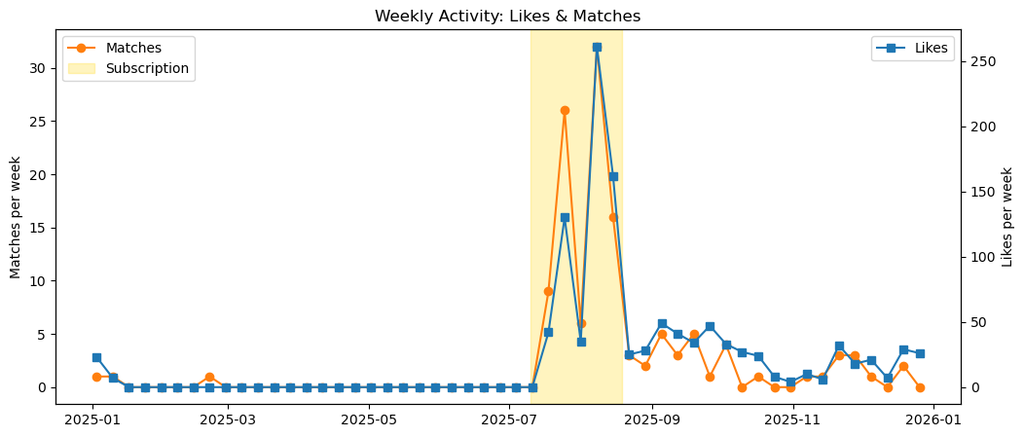

Clearly we can see that there is a period between July and August where both matches and likes considerably increase. This is the period I was in India and using Hinge with paid subscription. I highlight this period in Gold above. In the rest of the period I am using hinge in Europe/UK.

To see the impact of Subscription, below I show the match success rate for likes given in the subscription period vs those given outside.

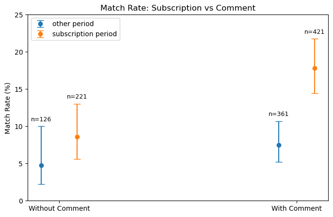

We can see that subscription roughly doubles the match success rate. So it does not make sense to simply combine the data in all the periods to obtain the true success rate of a comment.

To separate out the effect of the subscription period and obtain true success rate of each comments we will need to make some model assumptions and perform more careful analysis.

## 7. Bayesian Analysis

### 7.1 Generalized Linear Model

Here we will use a Bayesian approach to estimate the true success rate for the comments. I model the success probability, $p$, of a $i$ like I send, through

$$ p = \text{sigmoid}(\alpha + \beta \cdot \text{has\_comment} + \sum_{i\neq \text{random}} \beta_i \cdot \text{cluster}_i + B \cdot \text{in\_subscription}) $$

- Here the Sigmoid is a function that takes a number from between $-\infty$ to $\infty$ to a number between $0$ and 1. This ensures that our probability stays positive and smaller than 1.
- has_comment is 1 if I have a comment in the like I am sending, else has_comment is 0.
- in_subscription is 1 if the like I am sending is during the subscription period, else it is 0.
- $\text{cluster}_i$ is 1 if the comment in the like belongs to $i^{th}$ cluster. The sum is over all clusters except the cluster belonging to random comments (C7).
- $\alpha$, $\beta$, $\beta_i$, and $B$ are the model parameters that we will estimate using the data

**Implicit Model Assumptions**

1. All likes sent have a base matching probability determined by $\alpha$
2. All likes with a comment get a boost in probability determined by $\beta$
3. $\beta_i$ encodes the relative change in probability if a comment belongs to a specific $i^{th}$ cluster we identified before. Because comments in the 'random' cluster are hard to group together, we do not assign them a special $\beta_i$ and instead their probability are determined by the common $\beta$.
4. All likes get the same boost, $B$, in the subscription period regardless of what comment we send

By fitting the above model on the data we get posterior distributions on the moddel parameters, $\alpha$, $\beta$, etc. However, the estimates of just these parameters are harder to interpret and are also not what we actually care about.

Since I am interested in finding what actions we should take in the future, below I plot the relative increase in matching probability for different action choices, relative to the probability of sending like with random comment wihtout subscription. For e.g. for likes sent without comment we have, $$ \%\text{Relative probability}= \frac{\text{Sigmoid}(\alpha)-\text{Sigmoid}(\alpha+\beta)}{\text{Sigmoid}(\alpha+\beta)}\times 100 $$

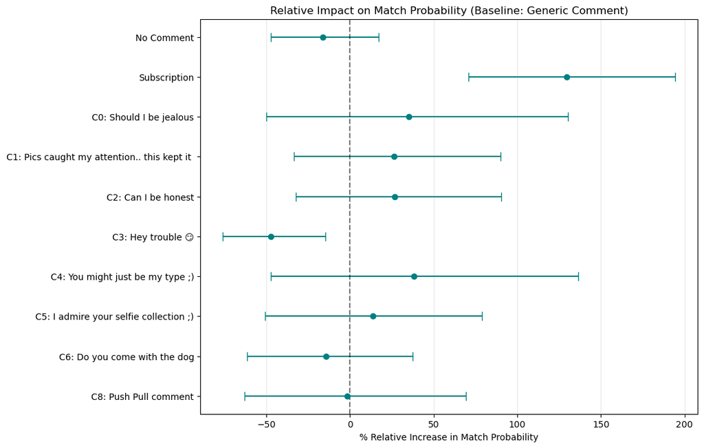

**Conclusions**: The only statistically significant conclusions we can draw is that we should avoid sending 'hey trouble' comment and to use subscription to increase future matching rate. The canned comments show decent superiority over generic comments and I should get more data on them to confirm their superiority.

### 7.2 (Optional) Beta Hierarchical Model

The previous model was one way we can model the matching rate. But since we do not know the exact theory we would like to avoid any systematic issues due to our modelling choices. So here I use a very different model to fit the data

I start by assuming that the matching probabilities of different choices (subscription, special comments, no comments, etc) are drawn from a common distribution: Beta Distribution with unknown parameters $\alpha$ and $\beta$. This base distribution is assumed to be determined by my Hinge profile and hence affects the success rate of all likes I send out.

Specifically, the Beta distribution determines the average success probability of any like I send out: $$\bar{p}=\frac{\alpha}{\alpha+\beta}$$.

To model the influence of subscription, I assume that having subscription shifts my whole Beta distribution, such that $$\bar{p}_{sub}=\text{max}(1,(1+B)\bar{p}),$$ where $B$ is the boost due to subscription.

[figure not shown]

## 10. Model Comparison

Comparing GLM and Beta Hierarchical models using LOO.

```
                   rank     elpd_loo     p_loo  elpd_diff    weight  \
GLM                   0  1364.540676  7.931100    0.00000  0.759664
Beta Hierarchical     1  1366.527196  5.701313    1.98652  0.240336

                          se       dse  warning     scale
GLM                55.951177  0.000000    False  deviance
Beta Hierarchical  55.908401  3.924535    False  deviance
```

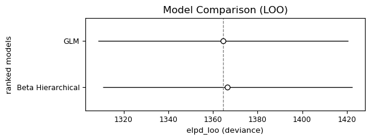

There is hardly any difference between the fits of the two models. So as per our current data both models are appropriate choices.

## Result from Data-driven choices

Using the knowledge gained from above analysis I made following two changes in my Hinge liking strategy:

1. Paid subscription
2. Sent comments belonging top 3 performing canned categories for all the likes.

Here are the results from ~100 likes I sent with above strategy

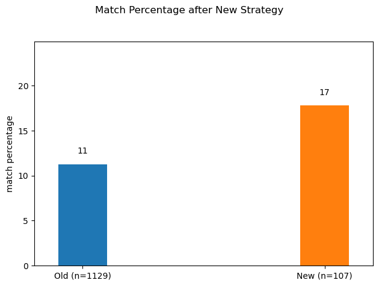

We see a roughly **60% increase** in match success rate!

## Future systematic checks

There are several other systematics that were not accounted for in the analysis.

1. My hinge account itself evolves over time. Hinge data does not have a history of my photo updates. I can log the dates of my photo updates and account for it in future data.
2. The probability of match success likely changes for girls with different Elo ratings. My succes of like is lower on a girl with much higher rating. Hinge ofcourse does not shore the rating of girl for every like. In future I plan on putting my rating of a girl in the comments I send out.